# Adopting functional perspectives

Hansjörg Neth, SPDS, uni.kn

2025-11-05

> The greatest value of a picture is when it forces us to notice what we never expected to see.  
> (John W. Tukey)[^1]

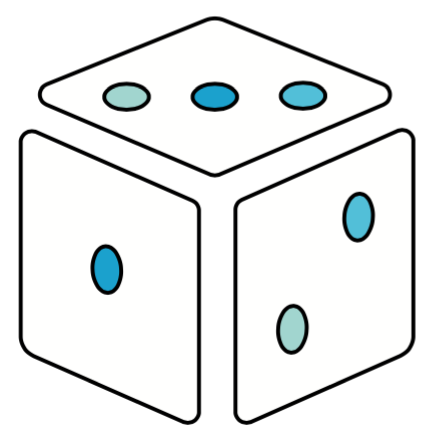

The key **riskyr** data structure essentially describes a network of dependencies. This is best illustrated by the network diagram (see examples of `plot_fnet()` in the user guide and data formats). However, sometimes it is instructive to view all possible values of a parameter as a function of some other variable. A functional perspective illustrates how the value of some variable (or its values) changes as a function of another (and their values).

## Functions

The basic format of a function is $y = f(x)$, which illustrates how values of $y$ depend on values of $x$ given some function $f$. **riskyr** provides two functions for viewing parameters as a function of other parameters (and their values).

## Curves as a function of prevalence

The `plot_curve()` function draws the curves (or lines) of selected parameters as a function of the prevalence (with `prev` ranging from 0 to 1) for a given decision process or diagnostic test (i.e., given values of `sens` and `spec`):

$$y \ = \ f(\texttt{prev} \textrm{, from 0
to 1}) \textrm{ with } y \in \{\texttt{PPV}, \texttt{NPV},
\texttt{ppod}, \texttt{acc}\} \ \ \ \ \ \ (1)$$

As an example, reconsider our original scenario (on mammography screening, see user guide). Earlier, we computed a positive predictive value (PPV) of 7.8%. But rather than just computing a single value, we could ask: How do values of PPV develop as a function of prevalence? The `plot_curve()` function illustrates this relationship:

```
#> Argument 'title_lbl' is deprecated. Please use 'main' instead.
```

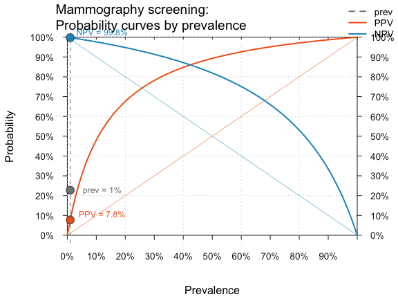

Showing PPV and NPV as a function of prevalence (for a prevalance of 1% and given values of sensitivity and specificity) in the original mammography screening scenario.

```r
plot_curve(prev = .01, sens = .80, spec = (1 - .096),
           what = c("prev", "PPV", "NPV"),
           title_lbl = "Mammography screening", cex.lbl = .8)
```

The curves illustrate that values of `PPV` and `NPV` crucially depend on the prevalence value `prev` in the current population. In fact, they actually vary across their entire range (i.e., from 0 to 1), rendering any communication of their value utterly meaningless without specifying the current population’s prevalence value.

The dependency of `PPV` and `NPV` on `prev` can be illustrated by assuming a higher prevalence rate. For instance, if we knew that some woman was genetically tested and known to exhibit the notorious BRCA1 mutation, the prevalence value of her corresponding population (given a positive mammography result in a routine screening) is increased to about 60% (graph not shown here to save space, but try running the following code for yourself):

```r
high.prev <- .60   # assume increased prevalence due to BRCA1 mutation

plot_curve(prev = high.prev, sens = .80, spec = (1 - .096),
           what = c("prev", "PPV", "NPV"),
           title_lbl = "Mammography screening (BRCA1 mutation)", cex.lbl = .80)
```

This shows that — given an increased prevalence value `prev` of 60% — the positive predictive value `PPV` of a positive test result increases from 7.8% (in the standard population) to around 93% (given the BRCA1 mutation).

In addition, the actual values of population and test parameters are often unclear. The `plot_curve()` function reflects this by providing an uncertainty parameter `uc` that is expressed as a percentage of the specified value. For instance, the following assumes that our parameter values may deviate up to 5% from the specified values and marks the corresponding ranges of uncertainty as shaded areas around the curves that assume exact parameter values.

Both the notions of expressing probabilities as a function of prevalence and of uncertainty ranges for imprecise parameter estimates can be extended to other probabilities. The following curves show the full set of curves currently drawn by `plot_curve()`. In addition to the predictive values `PPV` and `NPV`, we see that the bias or proportion of positive decisions `ppod` and the overall accuracy `acc` also vary as a function of the prevalence `prev`:

```
#> Argument 'title_lbl' is deprecated. Please use 'main' instead.
```

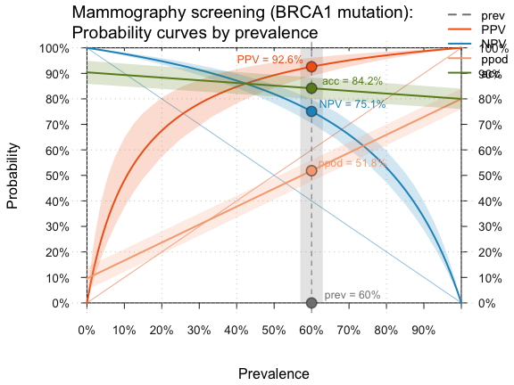

Curves that show PPV/NPV, ppod, and acc as a function of an prevalence (for given values of sensitivity and specificity) when assuming an increased prevalence of 60% and an uncertainty range of 5%.

```r
high.prev <- .60   # assume increased prevalence due to BRCA1 mutation

plot_curve(prev = high.prev, sens = .80, spec = (1 - .096),
           what = c("prev", "PPV", "NPV", "ppod", "acc"),
           title_lbl = "Mammography screening (BRCA1 mutation)", uc = .05, cex.lbl = .80)
```

## Planes as a function of sensitivity and specificity (given a prevalence)

The `plot_plane()` function draws a plane for a selected parameter as a function of sensitivity and specificity values (with `sens` and `spec` both ranging from 0 to 1) for a given prevalence `prev`:

$$y \ = \ f(\texttt{sens} \times\
\texttt{spec} \textrm{, both from 0 to 1, for given value of }
\texttt{prev}) \textrm{ with } y \in \{\texttt{PPV}, \texttt{NPV},
\texttt{ppod}, \texttt{acc}\} \ \ \ \ \ \ \ (2)$$

Some examples (not shown here, but please try evaluating the following function calls):

```
#> Argument 'title_lbl' is deprecated. Please use 'main' instead.
```

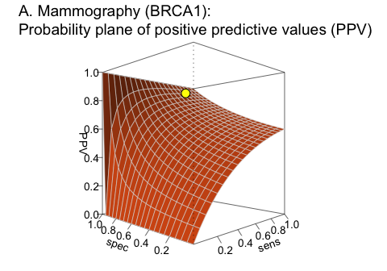

Plane showing the positive predictive value (PPV) as a function of sensitivity and specificity for a given prevalence.

```r
plot_plane(prev = high.prev, sens = .80, spec = (1 - .096), what = "PPV",
           title_lbl = "A. Mammography (BRCA1)", cex.lbl = .8)
```

Related plots (showing different probabilities) include:

```r
plot_plane(prev = high.prev, sens = .80, spec = (1 - .096), what = "NPV",
           title_lbl = "B. Mammography (BRCA1)", cex.lbl = .8)
plot_plane(prev = high.prev, sens = .80, spec = (1 - .096), what = "ppod", what_col = "firebrick",
           title_lbl = "C. Mammography (BRCA1)", phi = 45, cex.lbl = .8)
plot_plane(prev = high.prev, sens = .80, spec = (1 - .096), what = "acc",  what_col = "forestgreen",
           title_lbl = "D. Mammography (BRCA1)", cex.lbl = .8)
```

Overall, viewing conditional probabilities (like `PPV` or `NPV`, but also `ppod` or `acc`) as a function of other probabilities (e.g., `prev`, `sens`, `spec` or `fart`) often reveals unexpected relationships and can enable new insights.

### Resources

The following resources and versions are currently available:

| Type: | Version: | URL: |
| --- | --- | --- |
| A. **riskyr** (R package): | [Release version](https://CRAN.R-project.org/package=riskyr) | https://CRAN.R-project.org/package=riskyr |
|  | [Development version](https://github.com/hneth/riskyr/) | https://github.com/hneth/riskyr/ |
| B. **riskyrApp** (R Shiny code): | [Online version](https://riskyr.org/) | https://riskyr.org/ |
|  | [Development version](https://github.com/hneth/riskyrApp/) | https://github.com/hneth/riskyrApp/ |
| C. Online documentation: | [Release version](https://hneth.github.io/riskyr/) | https://hneth.github.io/riskyr/ |
|  | [Development version](https://hneth.github.io/riskyr/dev/) | https://hneth.github.io/riskyr/dev/ |

## Contact

We appreciate your feedback, comments, or questions.

- Please report any **riskyr**-related issues at https://github.com/hneth/riskyr/issues/.
- Contact us at contact.riskyr@gmail.com with any comments, questions, or suggestions.

## All riskyr vignettes

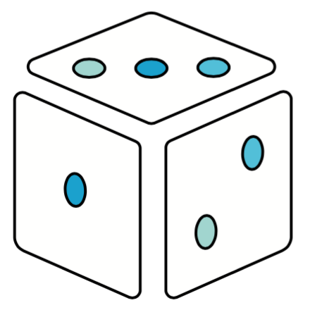

| Nr. | Vignette | Content |
| --- | --- | --- |
| A. | User guide | Motivation and general instructions |
| B. | Data formats | Data formats: Frequencies and probabilities |
| C. | Confusion matrix | Confusion matrix and accuracy metrics |
| D. | Functional perspectives | Adopting functional perspectives |
| E. | Quick start primer | A primer on using **riskyr** |

[^1]: Tukey, J.W. (1977), *Exploratory data analysis*. Reading, MA: Addison-Wesley. (p. vi).